# Exercise 1

Tan Hong Ming

August 13, 2018

## Reading the data

Here we read the excel file and check if the data read is correct using the head and tail function. Note we used excel preliminary to convert the .xls filetype to .csv.

```r
married.women.df = read.csv('csvExample1.csv')
head(married.women.df)  # check data
```

```
##   MARITAL UHOURS ln.hours. EARNHRE AGE NKIDS KID3DIFF ln.earn.
## 1       1     20      3.00     400  25     2        0     5.99
## 2       1     20      3.00    1600  25     2        0     7.38
## 3       1     40      3.69     540  25     2        0     6.29
## 4       1     40      3.69     350  25     2        0     5.86
## 5       1     40      3.69     485  25     2        0     6.18
## 6       1     40      3.69     637  26     2        0     6.46
```

```r
tail(married.women.df)  # check data
```

```
##     MARITAL UHOURS ln.hours. EARNHRE AGE NKIDS KID3DIFF ln.earn.
## 121       1     40      3.69     360  40     3        1     5.89
## 122       1     40      3.69     927  41     3        1     6.83
## 123       1     40      3.69     475  42     3        1     6.16
## 124       1     30      3.40     819  42     3        1     6.71
## 125       1     40      3.69     608  43     3        1     6.41
## 126       1     24      3.18     375  43     3        1     5.93
```

## Plotting the data

For illustrative purposes. Plotting is done using the “ggplot2” package. Documentation can be found at https://ggplot2.tidyverse.org/ Note: You may need to install the package first by using “install.packages(”ggplot2“)”.

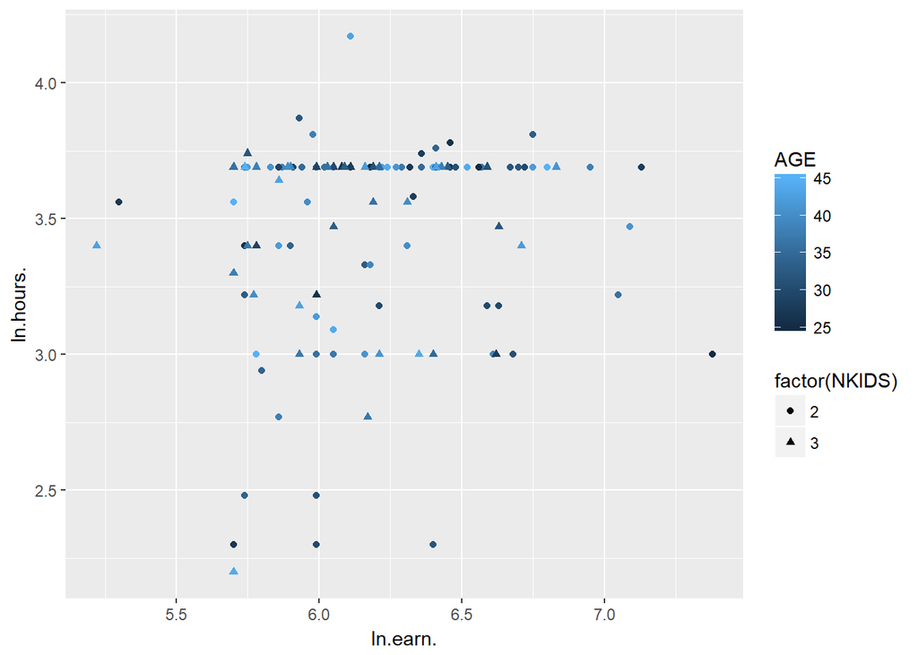

```r
library(ggplot2)  # load the ggplot2 package
ggplot(married.women.df) + geom_point(aes(ln.earn., ln.hours., colour = AGE, shape=factor(NKIDS)))
```

## Calculating the reduced forms

We use the lm function to perform the least sqaures approximation, then summary function to output a summary of the estimated model.

### Wage

```r
wage.reduced.form = lm(ln.earn. ~ NKIDS + AGE, data = married.women.df)
summary(wage.reduced.form)
```

```
##
## Call:
## lm(formula = ln.earn. ~ NKIDS + AGE, data = married.women.df)
##
## Residuals:
##      Min       1Q   Median       3Q      Max
## -0.94848 -0.29722 -0.02901  0.22525  1.12500
##
## Coefficients:
##              Estimate Std. Error t value Pr(>|t|)
## (Intercept)  6.590018   0.238031  27.686   <2e-16 ***
## NKIDS       -0.126725   0.070710  -1.792   0.0756 .
## AGE         -0.003263   0.005537  -0.589   0.5568
## ---
## Signif. codes:  0 '***' 0.001 '**' 0.01 '*' 0.05 '.' 0.1 ' ' 1
##
## Residual standard error: 0.3723 on 123 degrees of freedom
## Multiple R-squared:  0.03114,    Adjusted R-squared:  0.01539
## F-statistic: 1.977 on 2 and 123 DF,  p-value: 0.1429
```

### Hours

```r
hours.reduced.form = lm(ln.hours. ~ NKIDS + AGE, data = married.women.df)
summary(hours.reduced.form)
```

```
##
## Call:
## lm(formula = ln.hours. ~ NKIDS + AGE, data = married.women.df)
##
## Residuals:
##     Min      1Q  Median      3Q     Max
## -1.2609 -0.2223  0.2194  0.2273  0.7151
##
## Coefficients:
##               Estimate Std. Error t value Pr(>|t|)
## (Intercept)  3.4786266  0.2390045  14.555   <2e-16 ***
## NKIDS        0.0068992  0.0709993   0.097    0.923
## AGE         -0.0008735  0.0055593  -0.157    0.875
## ---
## Signif. codes:  0 '***' 0.001 '**' 0.01 '*' 0.05 '.' 0.1 ' ' 1
##
## Residual standard error: 0.3738 on 123 degrees of freedom
## Multiple R-squared:  0.0002463,  Adjusted R-squared:  -0.01601
## F-statistic: 0.01515 on 2 and 123 DF,  p-value: 0.985
```

## Structural

```r
structural.form = lm(ln.hours. ~ ln.earn., data = married.women.df)
summary(structural.form)
```

```
##
## Call:
## lm(formula = ln.hours. ~ ln.earn., data = married.women.df)
##
## Residuals:
##     Min      1Q  Median      3Q     Max
## -1.2073 -0.1776  0.1830  0.2373  0.7140
##
## Coefficients:
##             Estimate Std. Error t value Pr(>|t|)
## (Intercept)  2.73079    0.54552   5.006 1.86e-06 ***
## ln.earn.     0.11869    0.08812   1.347     0.18
## ---
## Signif. codes:  0 '***' 0.001 '**' 0.01 '*' 0.05 '.' 0.1 ' ' 1
##
## Residual standard error: 0.3696 on 124 degrees of freedom
## Multiple R-squared:  0.01442,    Adjusted R-squared:  0.006471
## F-statistic: 1.814 on 1 and 124 DF,  p-value: 0.1805
```

## Get wage predictions

Here we use our least squares approximation model of the wage to get predicted wages. We will use the predicted wages as an instrumental variable in the second step of the two stage least squares.

```r
p.df = predict(wage.reduced.form, married.women.df)
head(p.df)
```

```
##        1        2        3        4        5        6
## 6.255001 6.255001 6.255001 6.255001 6.255001 6.251739
```

```r
tail(p.df)
```

```
##      121      122      123      124      125      126
## 6.079336 6.076073 6.072811 6.072811 6.069548 6.069548
```

```r
married.women.df$predWage = p.df  # add the predicted values as a new column in our data frame
```

After this, we perform the second least squares approximation.

```r
struc.2sls.form = lm(ln.hours. ~ predWage, data = married.women.df)
summary(struc.2sls.form)
```

```
##
## Call:
## lm(formula = ln.hours. ~ predWage, data = married.women.df)
##
## Residuals:
##     Min      1Q  Median      3Q     Max
## -1.2656 -0.2240  0.2247  0.2263  0.7060
##
## Coefficients:
##             Estimate Std. Error t value Pr(>|t|)
## (Intercept)  3.54230    3.10834   1.140    0.257
## predWage    -0.01264    0.50301  -0.025    0.980
##
## Residual standard error: 0.3723 on 124 degrees of freedom
## Multiple R-squared:  5.09e-06,   Adjusted R-squared:  -0.008059
## F-statistic: 0.0006312 on 1 and 124 DF,  p-value: 0.98
```

## Testing for overindentification restrictions

First, we use our second stage model to predict hours, and calculate the prediction error

```r
p.df = predict(struc.2sls.form, married.women.df)
head(p.df)
```

```
##        1        2        3        4        5        6
## 3.463247 3.463247 3.463247 3.463247 3.463247 3.463289
```

```r
tail(p.df)
```

```
##      121      122      123      124      125      126
## 3.465467 3.465509 3.465550 3.465550 3.465591 3.465591
```

```r
married.women.df$error = married.women.df$ln.hours.- p.df
```

Next, we regress errors from second stage on the instrumental variables.

```r
sargan.test.model = lm(error ~ NKIDS + AGE, data = married.women.df)
summary(sargan.test.model)
```

```
##
## Call:
## lm(formula = error ~ NKIDS + AGE, data = married.women.df)
##
## Residuals:
##     Min      1Q  Median      3Q     Max
## -1.2609 -0.2223  0.2194  0.2273  0.7151
##
## Coefficients:
##               Estimate Std. Error t value Pr(>|t|)
## (Intercept)  0.0196129  0.2390045   0.082    0.935
## NKIDS        0.0052977  0.0709993   0.075    0.941
## AGE         -0.0009148  0.0055593  -0.165    0.870
##
## Residual standard error: 0.3738 on 123 degrees of freedom
## Multiple R-squared:  0.0002413,  Adjusted R-squared:  -0.01601
## F-statistic: 0.01484 on 2 and 123 DF,  p-value: 0.9853
```

Now we calculate our test-statistic.

```r
test.stat = summary(sargan.test.model)$r.squared * nrow(married.women.df) # summary(sargan.test.model)$df[2]
p.value = pchisq(test.stat, 1, lower.tail = FALSE)
```

| test statistic | p value |
| --- | --- |
| 0.0303985 | 0.8615891 |

## Direct two stage least squares with diagnostic tests

We can also perform the two stage least squares directly using R. For this, we use the ivreg() function in the AER package. Note: you may need to install the package first by using “install.packages(”AER“)”.

```r
library(AER)  # load the AER package
direct.2sls.form = ivreg(ln.hours. ~ ln.earn.| NKIDS + AGE, data = married.women.df)
summary(direct.2sls.form, diagnostics = TRUE)
```

```
##
## Call:
## ivreg(formula = ln.hours. ~ ln.earn. | NKIDS + AGE, data = married.women.df)
##
## Residuals:
##     Min      1Q  Median      3Q     Max
## -1.2703 -0.2175  0.2218  0.2280  0.7049
##
## Coefficients:
##             Estimate Std. Error t value Pr(>|t|)
## (Intercept)  3.54230    3.11337   1.138    0.257
## ln.earn.    -0.01264    0.50382  -0.025    0.980
##
## Diagnostic tests:
##                  df1 df2 statistic p-value
## Weak instruments   2 123     1.977   0.143
## Wu-Hausman         1 123     0.071   0.791
## Sargan             1  NA     0.030   0.862
##
## Residual standard error: 0.3729 on 124 degrees of freedom
## Multiple R-Squared: -0.003234,   Adjusted R-squared: -0.01132
## Wald test: 0.0006292 on 1 and 124 DF,  p-value: 0.98
```